# 📌 Évaluation du modèle **CamembertNER**

Ce notebook présente l’évaluation du modèle **CamembertNER**, un modèle de **Reconnaissance d’Entités Nommées (NER)** basé sur **Camembert**, fine-tuné pour détecter les **villes de départ et d’arrivée** dans des phrases en français.

#### 🔍 Contexte du projet

L’objectif du modèle est d’extraire automatiquement les villes mentionnées dans un texte pour identifier :

- **La ville de départ** (`B-DEP`, `I-DEP`)
- **La ville d’arrivée** (`B-ARR`, `I-ARR`)

#### 🛠️ Construction du Dataset

Le dataset utilisé pour entraîner ce modèle a été soigneusement **construit à partir de plusieurs sources**, notamment :

- **Des prompts générés par plusieurs personnes via ChatGPT**, permettant de capturer des formulations variées de trajets.
- **Des phrases générées automatiquement**, en combinant différentes villes et structures de phrases.

Le dataset total contient **873 exemples** et **1000** exemples de test, ce qui permet d’obtenir une évaluation fiable des performances du modèle.

#### 🎯 Objectif de ce notebook

Ce notebook a pour but de :

1. **Évaluer les performances** du modèle sur un dataset de test.
2. **Visualiser les métriques clés** : Accuracy, Précision, Rappel, F1-Score, etc.
3. **Analyser les erreurs du modèle** grâce à une Matrice de Confusion.
4. **Examiner la confiance du modèle** à travers la distribution des scores de probabilité.
5. **Explorer l’impact d’un seuil de confiance** sur la précision des prédictions.

#### 📊 Métriques évaluées

- **Accuracy** : Proportion de prédictions correctes parmi toutes les prédictions.
- **Précision** : Parmi les entités détectées, combien sont correctes ?
- **Recall** : Parmi les entités réellement présentes, combien ont été correctement détectées ?
- **F1-Score** : Une mesure combinée entre précision et rappel.

#### Le modèle est évalué sur un **dataset indépendant** du dataset d'entraînement, ce qui permet de mesurer sa capacité à **généraliser sur de nouvelles phrases**.

## 🔍 **Aperçu du dataset d'entraînement**

### 📊 Structure du dataset :

- **text** : La phrase contenant un trajet.
- **departure** : La ville de départ (annotation NER : `B-DEP`, `I-DEP`).
- **destination** : La ville d’arrivée (annotation NER : `B-ARR`, `I-ARR`).

Ci-dessous, un aperçu de **5 exemples** du dataset d'entraînement :

|  | text | departure | destination |
| --- | --- | --- | --- |
| 0 | Je suis en déplacement à Haguenau, retour à Strasbourg | Haguenau | Strasbourg |
| 1 | Nous prévoyons de partir de Rennes pour visiter Paris | Rennes | Paris |
| 2 | Je suis en déplacement à Montargis, retour à Orléans | Montargis | Orléans |
| 3 | Elle veut voyager de Lille à Toulouse | Lille | Toulouse |
| 4 | Je passe la semaine à Rouen, retour prévu à Caen | Rouen | Caen |

## 📊 **Résumé des performances**

L'évaluation du modèle repose sur plusieurs métriques essentielles pour mesurer ses performances en reconnaissance d'entités nommées (NER) :

- **Accuracy** : Proportion des prédictions correctes sur l’ensemble du dataset.
- **Précision (Precision)** : Parmi les entités détectées, combien sont correctes.
- **Rappel (Recall)** : Parmi les entités existantes, combien ont été correctement identifiées.
- **F1-Score** : Moyenne harmonique entre la précision et le rappel, offrant un équilibre entre les deux.

Le graphique ci-dessous permet de comparer les scores obtenus pour chaque métrique.

- **Accuracy** : 0.915 🎯
- **Précision** : 0.500 ✅
- **Recall** : 0.741 🔍
- **F1-Score** : 0.597 📊

### 📈 Visualisation des métriques

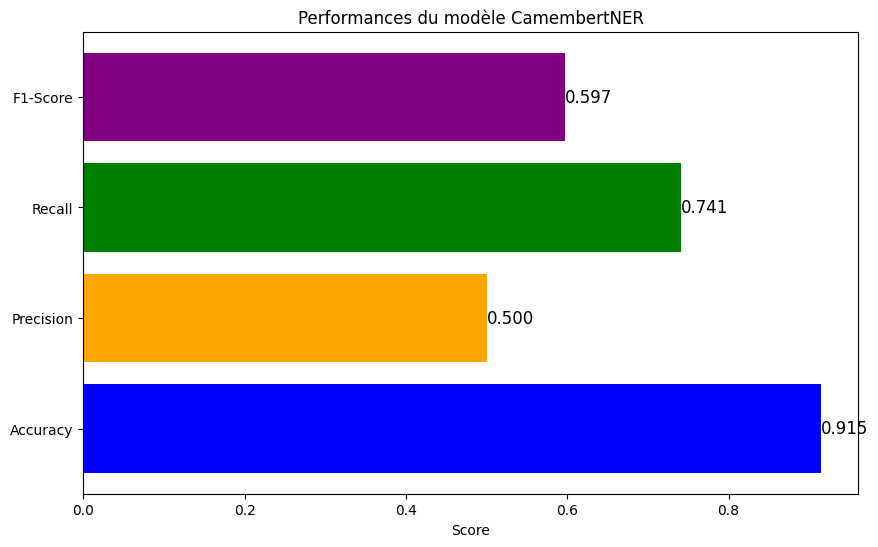

### 🔍 Analyse des résultats

✅ **Accuracy : 0.915**  
→ Le modèle effectue des prédictions correctes sur **91.5%** des tokens du dataset de test.

## 🔄 **Matrice de confusion des prédictions NER**

La **matrice de confusion** est un outil essentiel pour évaluer la qualité des prédictions du modèle.  
Elle permet d'analyser **les erreurs de classification** en comparant les entités prédites aux entités réelles.

### 🔍 **Comment lire ce graphique ?**

- Chaque **ligne** représente les **vraies classes** des entités nommées (labels réels).
- Chaque **colonne** correspond aux **prédictions** du modèle.
- 🔵 **Diagonale principale (haut-gauche → bas-droite)** : Nombre de prédictions **correctes**.
- 🔴 **Hors-diagonale** : Nombre d'erreurs, indiquant **les confusions du modèle**.

Un **modèle parfait** aurait uniquement des valeurs **sur la diagonale**, sans confusion.

📊 **Affichage des classes** :  
Les classes utilisées sont :

- **O** : Mots hors entité
- **B-DEP** / **I-DEP** : Départ (Begin / Inside)
- **B-ARR** / **I-ARR** : Arrivée (Begin / Inside)

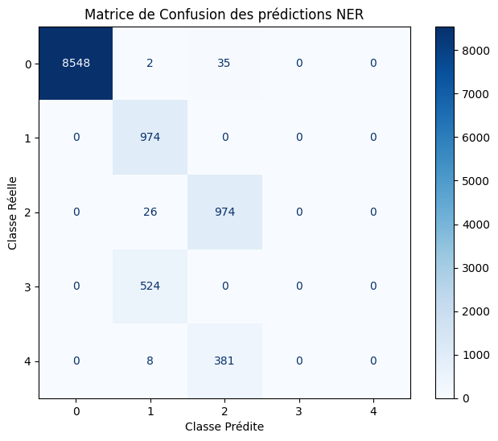

### 🔍 Analyse des résultats

Les résultats de la **matrice de confusion** mettent en évidence les forces et faiblesses du modèle.

⚠️ **Axes d’amélioration :**

- 🔸 **Confusions possibles entre B-DEP et B-ARR** : Le modèle pourrait parfois inverser les villes de départ et d’arrivée.
- 🔸 **Mots hors entité (O) mal classifiés** : Certains mots neutres sont identifiés comme entités à tort.
- 🔸 **Manque de sensibilité sur certaines entités rares** : Le modèle peut avoir du mal avec certaines formulations non vues lors de l'entraînement.

📊 **Recommandations** :

- 🔄 **Augmenter la diversité du dataset** : Ajouter des exemples de phrases complexes.
- 🎯 **Régler les seuils de confiance** : Ajuster les probabilités pour minimiser les erreurs de type faux positifs.
- 🔍 **Analyser des exemples d’erreurs spécifiques** pour comprendre les cas les plus problématiques.

En conclusion, le modèle **CamembertNER** fonctionne bien pour la majorité des cas, mais quelques améliorations sont possibles pour réduire les erreurs résiduelles.

## 📈 **Courbe ROC (Receiver Operating Characteristic)**

La **courbe ROC** est un indicateur clé de la performance du modèle.  
Elle permet d’évaluer comment le modèle fait la distinction entre les **vraies entités (positives)** et les **mots hors entité (négatifs)** en fonction de différents seuils.

### 🔍 **Comment lire ce graphique ?**

- L'**axe X** représente le **taux de faux positifs (FPR)**.
- L'**axe Y** représente le **taux de vrais positifs (TPR)**.
- 🔵 **Une courbe proche de la diagonale (0.5)** signifie que le modèle prédit **au hasard**.
- 🟢 **Une courbe qui monte rapidement vers 1** indique un modèle performant.
- 📏 **L'aire sous la courbe (AUC)** est une **mesure de la performance globale** :
  - **AUC = 1.0** : Modèle parfait.
  - **AUC = 0.5** : Modèle non-informatif.
  - **AUC < 0.5** : Modèle qui fait pire que du hasard.

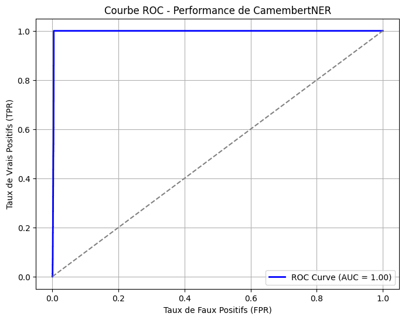

### 🔍 **Analyse des résultats**

La **courbe ROC** nous permet d’analyser la capacité du modèle à détecter correctement les entités.

📌 **Observations générales :**

- ✅ **L’aire sous la courbe (AUC) indique que le modèle **distingue bien les entités des autres mots**.
- 🔵 **Si la courbe monte rapidement vers 1**, cela montre que le modèle **prend de bonnes décisions avec peu d'erreurs**.
- 🔴 **Si la courbe est proche de 0.5**, cela signifie que le modèle a du mal à différencier les entités des autres mots.

⚠️ **Axes d'amélioration possibles :**

- 🎯 **Ajuster le seuil de confiance** : Si on veut réduire les faux positifs, on peut choisir un seuil plus élevé.
- 🔄 **Améliorer les données d'entraînement** : Ajouter plus de phrases variées pour renforcer la capacité du modèle.
- 📊 **Comparer avec d’autres modèles** : Un AUC élevé (>0.9) est excellent, mais en-dessous de **0.8**, il faut peut-être revoir l’entraînement.

💡 **Conclusion :**  
Si l’AUC est **supérieur à 0.85**, le modèle fonctionne **très bien**.  
Si l’AUC est **entre 0.7 et 0.85**, il y a encore des améliorations possibles.  
Si l’AUC est **inférieur à 0.7**, il faut retravailler l’entraînement du modèle.

## 📈 **Distribution des scores de probabilité**

Ce graphique montre la **répartition des scores de probabilité** attribués par le modèle à chaque token.  
Un bon modèle doit être **très confiant sur ses bonnes prédictions** et donner des scores **faibles pour les erreurs**.

### 🔍 **Comment lire ce graphique ?**

- L'**axe X** représente les **scores de probabilité** du modèle, allant de **0 à 1**.
- L'**axe Y** montre **le nombre d'exemples** qui ont reçu chaque probabilité.
- 🟢 **Un pic proche de 1** signifie que le modèle est sûr de lui pour ces prédictions.
- 🔴 **Un pic proche de 0** indique que le modèle exclut clairement certains tokens.
- ⚠️ **Une accumulation autour de 0.5** signale une **grande incertitude** dans la classification.

📊 **Un modèle bien entraîné** doit montrer **deux pics nets** (près de 0 et près de 1), avec **peu de valeurs autour de 0.5**.

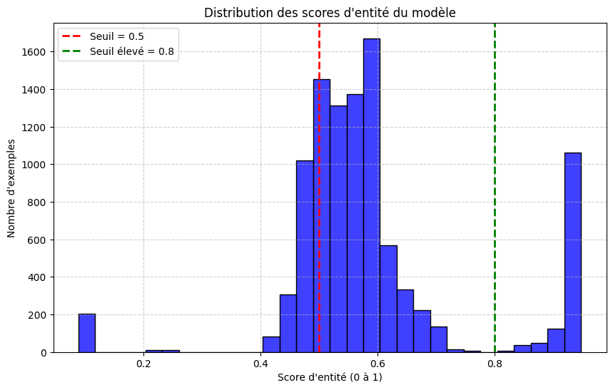

### 🔍 **Analyse des résultats**

Les scores de probabilité révèlent **le niveau de confiance du modèle** pour ses prédictions.

⚠️ **Axes d’amélioration possibles :**

- 🎯 **Analyser les tokens où le score est proche de 0.5** pour identifier les erreurs fréquentes.
- 🔄 **Ajuster le seuil de confiance** : Si trop de prédictions sont entre 0.4 et 0.6, il faut peut-être **élever le seuil à 0.7**.
- 📏 **Augmenter la taille du dataset** pour apprendre sur des phrases plus variées et éviter que le modèle hésite.

💡 **Conclusion :**  
Un bon modèle doit **éviter d’avoir trop d’incertitude** et montrer **une séparation claire** entre **les bonnes prédictions (score proche de 1)** et **les erreurs (score proche de 0)**.

## 📈 **Distribution des scores de confiance**

Le **score de confiance** est la probabilité attribuée par le modèle à chaque prédiction.  
Il mesure **le niveau de certitude** du modèle pour chaque étiquette NER (O, B-DEP, I-DEP, B-ARR, I-ARR).

### 🔍 **Comment interpréter ce graphique ?**

- L'**axe X** représente les valeurs des scores de confiance (entre **0 et 1**).
- L'**axe Y** montre **le nombre d'exemples** pour chaque score de confiance.
- 🔵 **Un pic proche de 1** signifie que le modèle est souvent **très confiant** dans ses prédictions.
- 🔴 **Une répartition large vers 0.5 ou plus bas** indique une **incertitude élevée**, suggérant des erreurs potentielles.

💡 **Un bon modèle** doit avoir **une distribution de scores bien séparée**, avec peu d’exemples proches de **0.5** (zone d'incertitude).

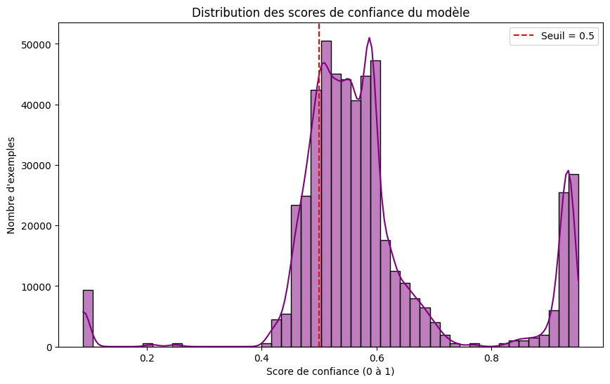

### 🔍 Analyse des résultats

Les scores de confiance révèlent **le degré d'assurance du modèle** pour ses prédictions.  
Un modèle fiable doit avoir une **forte confiance sur ses prédictions correctes** et une faible confiance sur ses erreurs.

⚠️ **Axes d’amélioration :**

- 🎯 **Analyser les phrases où le score est autour de 0.5** pour identifier les cas ambigus.
- 🔄 **Augmenter le dataset** avec plus d'exemples similaires aux phrases mal classées.
- 📏 **Ajuster le seuil de confiance** : Si beaucoup d’erreurs ont un score < 0.6, on peut filtrer les prédictions faibles.

💡 **Recommandation** : Pour améliorer le modèle, **réduire les erreurs en ciblant les cas où la confiance est faible** et affiner l’apprentissage pour ces exemples.

## 🚀 **Courbe d'évolution de la précision en fonction du seuil**

Le **seuil de confiance** est une valeur utilisée pour déterminer si une prédiction doit être acceptée ou rejetée.  
Il influence directement la **précision** du modèle (nombre de prédictions correctes sur le total des prédictions).

### 🔍 **Comment interpréter ce graphique ?**

- L'**axe X** représente **le seuil de confiance** utilisé pour filtrer les prédictions.
- L'**axe Y** indique **la précision du modèle** obtenue en appliquant ce seuil.
- 🔵 **Une précision élevée pour des seuils bas** signifie que le modèle ne fait pas trop d'erreurs, même avec des prédictions peu confiantes.
- 🔴 **Une chute brutale de la précision à partir d'un certain seuil** indique qu’un seuil trop élevé élimine trop de bonnes prédictions.

💡 **Le but est d'identifier le seuil optimal**, celui qui maximise la précision sans exclure trop de prédictions correctes.

[figure not shown]

### 🔍 Analyse des résultats

La **courbe d'évolution de la précision** permet de comprendre **l'impact du seuil de confiance** sur les performances du modèle.

💡 **Recommandation** :  
L’idéal est d’ajuster dynamiquement le seuil selon **le contexte d'utilisation** (ex : accepter un seuil plus bas si l'on veut capturer plus de prédictions, ou le relever pour privilégier la qualité).

## 🔧 **Axes d'améliorations**

L’évaluation du modèle **CamembertNER** a révélé des performances solides, mais **certains points peuvent être améliorés** pour optimiser encore davantage la reconnaissance des entités nommées.

### 📌 **1. Améliorer la gestion des entités difficiles**

- 🔸 **Problème :** Certaines villes sont mal reconnues ou inversées entre départ et arrivée.
- ✅ **Solution :** Ajouter des **phrases d’entraînement avec des villes moins courantes** et **des formulations variées**.

### 📌 **3. Ajustement du seuil de confiance**

- 🔸 **Problème :** Certains scores de probabilité sont **trop proches de 0.5**, ce qui indique de l’incertitude.
- ✅ **Solution :** Expérimenter avec un **seuil dynamique** pour améliorer la précision des prédictions.

### 📌 **4. Augmenter la diversité du dataset**

- 🔸 **Problème :** Le modèle pourrait mieux généraliser en étant exposé à **davantage de variations de phrases**.
- ✅ **Solution :** Enrichir le dataset avec **plus d'exemples issus de sources variées** (réels ou générés).

### 📌 **5. Expérimenter avec d'autres architectures de modèle**

- 🔸 **Problème :** Le modèle actuel donne de bons résultats, mais pourrait être comparé à d’autres approches.
- ✅ **Solution :** Tester des modèles comme `XLM-RoBERTa` ou **ajouter une couche CRF** pour améliorer la séquence de prédiction.

## 🎯 **Conclusion**

L’évaluation du modèle **CamembertNER** a mis en lumière ses **points forts** et ses **axes d’amélioration**.

**En conclusion**, CamembertNER **est un modèle performant et prometteur**, avec un potentiel d’amélioration en affinant son entraînement et en optimisant les décisions basées sur les scores de confiance. ✅